# R Data Cleaning

## String Functions using stringR

```r
str_detect(demographics$GENDER,'F')
```

```
 [1]  TRUE  TRUE  TRUE  TRUE FALSE  TRUE FALSE FALSE  TRUE FALSE  TRUE FALSE FALSE  TRUE  TRUE FALSE FALSE  TRUE FALSE  TRUE
```

```r
str_which(demographics$GENDER,'F')
```

```
 [1]  1  2  3  4  6  9 11 14 15 18 20
```

```r
str_count(demographics$GENDER,'F')
```

```
 [1] 1 1 1 1 0 1 0 0 1 0 1 0 0 1 1 0 0 1 0 1
```

```r
str_locate(demographics$GENDER,'F')
```

```
      start end
 [1,]     1   1
 [2,]     1   1
 [3,]     1   1
 [4,]     1   1
 [5,]    NA  NA
 [6,]     1   1
 [7,]    NA  NA
 [8,]    NA  NA
 [9,]     1   1
[10,]    NA  NA
[11,]     1   1
[12,]    NA  NA
[13,]    NA  NA
[14,]     1   1
[15,]     1   1
[16,]    NA  NA
[17,]    NA  NA
[18,]     1   1
[19,]    NA  NA
[20,]     1   1
```

*String Length* - str_length: returns string length - str_truc: truncates string - str_trim: removes whitespace - str_pad: makes all strings the same length

```r
teststr <- c("banana","strawberry","pineapple", " apple ")
str_length(teststr)
```

```
[1]  6 10  9  7
```

```r
str_trunc(teststr,6)
```

```
[1] "banana" "str..." "pin..." " ap..."
```

```r
str_trim(teststr)
```

```
[1] "banana"     "strawberry" "pineapple"  "apple"
```

*Order* - str_order: returns vector indexes in sort order - str_sort: returns vector in sort order

```r
str_order(teststr)
```

```
[1] 4 1 3 2
```

```r
str_sort(teststr)
```

```
[1] " apple "    "banana"     "pineapple"  "strawberry"
```

*Capitilization*

- str_to_upper: returns strings in upper case
- str_to_lower: returns string in lower case
- str_to_title: return string to title case, first letter in each word is capitalized

```r
str_to_upper(teststr)
```

```
[1] "BANANA"     "STRAWBERRY" "PINEAPPLE"  " APPLE "
```

```r
str_to_lower(teststr)
```

```
[1] "banana"     "strawberry" "pineapple"  " apple "
```

```r
str_to_title(str_c(teststr, sep=" ",collapse = " "))
```

```
[1] "Banana Strawberry Pineapple  Apple "
```

*Concat and Split* - str_c: Concat Vectors ir Strings Inside of a Vector - str_dup: Duplicate - str_glue: Create String with String and Variables - str_split_fixed: Split a vector of strings into a matrix of substrings - str_split: Split a vector of strings into a matrix of substrings

```r
str_c(teststr, teststr, sep=" ")
str_c(teststr, collapse = " ")
str_dup(teststr,3)
```

```r
firstname <- "Firstname"
lastname <- "Lastname"
course <- "Data Science for Biologist"
startdate <- as.Date("2020-01-10")
str_glue(
  "Dear {firstname} {lastname}: ",
  "Congratulations, you have been accepted into the {course} Nanocourse, ",
  "starting on {format(startdate, '%A, %B %d, %Y')}."
)
```

```r
str_split(teststr,"",4)
str_split(teststr,"a")
str_split_fixed(teststr,"",4)
```

*Subset* - str_sub: Extract substrings from a character vector. - str_subset: Return only the strings that contain a pattern match. - str_extract: Return the first pattern match found in each string, as a vector. - str_extract_all: Return the all pattern matches found in each string, as a vector. - str_match: Return the first pattern match found in each string, as a matrix with a column for each ( ) group in pattern - str_match_all: Return the all pattern match found in each string, as a matrix with a column for each ( ) group in pattern

```r
str <- c("Mouse:C57BL:WT:001","Mouse:C57BL:WT:002","Mouse:C57BL:KO:001","Mouse:C57BL:KO:002","Mouse:B6129SF2:WT:001","Mouse:B6129SF2:WT:002","Mouse:B6129SF2:KO:001","Mouse:B6129SF2:KO:002")
str_sub(str,6)
```

```
[1] ":C57BL:WT:001"    ":C57BL:WT:002"    ":C57BL:KO:001"    ":C57BL:KO:002"    ":B6129SF2:WT:001" ":B6129SF2:WT:002" ":B6129SF2:KO:001"
[8] ":B6129SF2:KO:002"
```

```r
str_sub(str,-6)
```

```
[1] "WT:001" "WT:002" "KO:001" "KO:002" "WT:001" "WT:002" "KO:001" "KO:002"
```

```r
str_sub(str,1,4)
```

```
[1] "Mous" "Mous" "Mous" "Mous" "Mous" "Mous" "Mous" "Mous"
```

```r
str_subset(str,"1")
```

```
[1] "Mouse:C57BL:WT:001"    "Mouse:C57BL:KO:001"    "Mouse:B6129SF2:WT:001" "Mouse:B6129SF2:WT:002" "Mouse:B6129SF2:KO:001"
[6] "Mouse:B6129SF2:KO:002"
```

```r
str_match(str,"1")
```

```
     [,1]
[1,] "1"
[2,] NA
[3,] "1"
[4,] NA
[5,] "1"
[6,] "1"
[7,] "1"
[8,] "1"
```

```r
str_match_all(str,"1")
```

```
[[1]]
     [,1]
[1,] "1"

[[2]]
     [,1]

[[3]]
     [,1]
[1,] "1"

[[4]]
     [,1]

[[5]]
     [,1]
[1,] "1"
[2,] "1"

[[6]]
     [,1]
[1,] "1"

[[7]]
     [,1]
[1,] "1"
[2,] "1"

[[8]]
     [,1]
[1,] "1"
```

### Inconsistent Data Entry

Check the gender categories in the demographics table

`r`r unique(demographics$GENDER)

```
[1] \FEMALE\ \F\      \M\      \MALE\   \FE\
```

*Replace Data Entry Mistakes*

Update the Gender Column to Make 2 GENDER Categories M and F

```r
demographics$GENDER <- str_replace(demographics$GENDER,'F.+','F')
demographics$GENDER <- str_replace(demographics$GENDER,'MALE','M')
unique(demographics$GENDER)
```

[output not shown]

## Reshaping Data: Gather and Spread

`r`r deathrates$Race <- str_replace(deathrates$Race,‘All Races’,‘All’) head(deathrates)

```
# A tibble: 6 x 4
   Year Race  Sex        AverageLifeExpectancy_Years
  <dbl> <chr> <chr>                            <dbl>
1  2015 All   Both Sexes                        NA
2  2014 All   Both Sexes                        78.9
3  2013 All   Both Sexes                        78.8
4  2012 All   Both Sexes                        78.8
5  2011 All   Both Sexes                        78.7
6  2010 All   Both Sexes                        78.7
```

`r`r filter(deathrates,Year==1900)

```
# A tibble: 9 x 4
   Year Race  Sex        AverageLifeExpectancy_Years
  <dbl> <chr> <chr>                            <dbl>
1  1900 All   Both Sexes                        47.3
2  1900 All   Female                            48.3
3  1900 All   Male                              46.3
4  1900 Black Both Sexes                        33
5  1900 Black Female                            33.5
6  1900 Black Male                              32.5
7  1900 White Both Sexes                        47.6
8  1900 White Female                            48.7
9  1900 White Male                              46.6
```

```
# A tibble: 6 x 5
   Year Sex          All Black White
  <dbl> <chr>      <dbl> <dbl> <dbl>
1  1900 Both Sexes  47.3  33    47.6
2  1900 Female      48.3  33.5  48.7
3  1900 Male        46.3  32.5  46.6
4  1901 Both Sexes  49.1  33.7  49.4
5  1901 Female      50.6  35.3  51
6  1901 Male        47.6  32.2  48
```

`r`r head(dr2)

```
# A tibble: 6 x 4
   Year Sex        Race  AvgLifeExpectancy
  <dbl> <chr>      <chr>             <dbl>
1  1900 Both Sexes All                47.3
2  1900 Female     All                48.3
3  1900 Male       All                46.3
4  1901 Both Sexes All                49.1
5  1901 Female     All                50.6
6  1901 Male       All                47.6
```

# Transpose A Table

```
   rows two three
1   one   1     1
2   two   2     2
3 three   3     3
```

`r`r df2 <- df1 %>% gather(newrows,valname,-rows) %>% spread(rows,valname) df2

```
  newrows one three two
1   three   1     3   2
2     two   1     3   2
```

## Split and Join Cells

```
# A tibble: 6 x 8
  PAT_ID  GENDER BirthDayOfMonth BirthMonth BirthYear DEATH_DATE RACE    ETHNICITY
  <chr>   <chr>  <chr>           <chr>      <chr>     <chr>      <chr>   <chr>
1 Z583990 F      27              JUN        57        <NA>       White   Hispanic
2 Z558145 F      14              MAR        54        26-MAR-12  Black   Non-hispanic
3 Z341881 F      13              JUN        40        <NA>       AA      Non-hispanic
4 Z795049 F      20              APR        81        <NA>       White   Non-hispanic
5 Z741693 M      19              DEC        75        <NA>       White   Non-hispanic
6 Z233337 F      18              DEC        36        <NA>       Unknown @
```

```
# A tibble: 6 x 5
  PAT_ID  GENDER BIRTH_DATE DEATH_DATE Population
  <chr>   <chr>  <chr>      <chr>      <chr>
1 Z583990 F      27-JUN-57  <NA>       White Hispanic
2 Z558145 F      14-MAR-54  26-MAR-12  Black Non-hispanic
3 Z341881 F      13-JUN-40  <NA>       AA Non-hispanic
4 Z795049 F      20-APR-81  <NA>       White Non-hispanic
5 Z741693 M      19-DEC-75  <NA>       White Non-hispanic
6 Z233337 F      18-DEC-36  <NA>       Unknown @
```

separate_rows allows for the separation to generate multiple rows

## Expand Table

`r`r deathrates[is.na(deathrates$AverageLifeExpectancy_Years),]

```
# A tibble: 9 x 4
   Year Race  Sex        AverageLifeExpectancy_Years
  <dbl> <chr> <chr>                            <dbl>
1  2015 All   Both Sexes                          NA
2  2015 All   Female                              NA
3  2015 All   Male                                NA
4  2015 Black Both Sexes                          NA
5  2015 Black Female                              NA
6  2015 Black Male                                NA
7  2015 White Both Sexes                          NA
8  2015 White Female                              NA
9  2015 White Male                                NA
```

`r`r t1[is.na(t1$AverageLifeExpectancy_Years),]

```
# A tibble: 0 x 4
# ... with 4 variables: Year <dbl>, Race <chr>, Sex <chr>, AverageLifeExpectancy_Years <dbl>
```

`r`r t3 <- complete(t1,Year=1900:2015,Race=c(‘All’,‘Black’,‘White’),Sex=c(‘Both Sexes’,‘Male’,‘Female’)) t1[is.na(t1$AverageLifeExpectancy_Years),]

```
# A tibble: 0 x 4
# ... with 4 variables: Year <dbl>, Race <chr>, Sex <chr>, AverageLifeExpectancy_Years <dbl>
```

`r`r t3[is.na(t3$AverageLifeExpectancy_Years),]

```
# A tibble: 354 x 4
    Year Race  Sex        AverageLifeExpectancy_Years
   <dbl> <chr> <chr>                            <dbl>
 1  1900 All   Both Sexes                          NA
 2  1900 All   Female                              NA
 3  1900 All   Male                                NA
 4  1901 All   Both Sexes                          NA
 5  1901 All   Female                              NA
 6  1901 All   Male                                NA
 7  1902 All   Both Sexes                          NA
 8  1902 All   Female                              NA
 9  1902 All   Male                                NA
10  1903 All   Both Sexes                          NA
# ... with 344 more rows
```

`r`r t4 <- complete(t1,Year=1900:2015,Race=c(‘All’,‘Black’,‘White’),Sex=c(‘Both Sexes’,‘Male’,‘Female’),fill=list(AverageLifeExpectancy_Years=68)) t4[t4$Year>2014,]

```
# A tibble: 9 x 4
   Year Race  Sex        AverageLifeExpectancy_Years
  <dbl> <chr> <chr>                            <dbl>
1  2015 All   Both Sexes                          68
2  2015 All   Female                              68
3  2015 All   Male                                68
4  2015 Black Both Sexes                          68
5  2015 Black Female                              68
6  2015 Black Male                                68
7  2015 White Both Sexes                          68
8  2015 White Female                              68
9  2015 White Male                                68
```

`r`r df <- tibble( year = c(2010, 2010, 2010, 2010, 2012, 2012, 2012), qtr = c( 1, 2, 3, 4, 1, 2, 3), return = rnorm(7) ) df %>% expand(year = full_seq(2010:2012, 1), qtr)

```
# A tibble: 12 x 2
    year   qtr
   <dbl> <dbl>
 1  2010     1
 2  2010     2
 3  2010     3
 4  2010     4
 5  2011     1
 6  2011     2
 7  2011     3
 8  2011     4
 9  2012     1
10  2012     2
11  2012     3
12  2012     4
```

## Merging Tables

1. Create a data frame of BMI for the patients in demographics

#

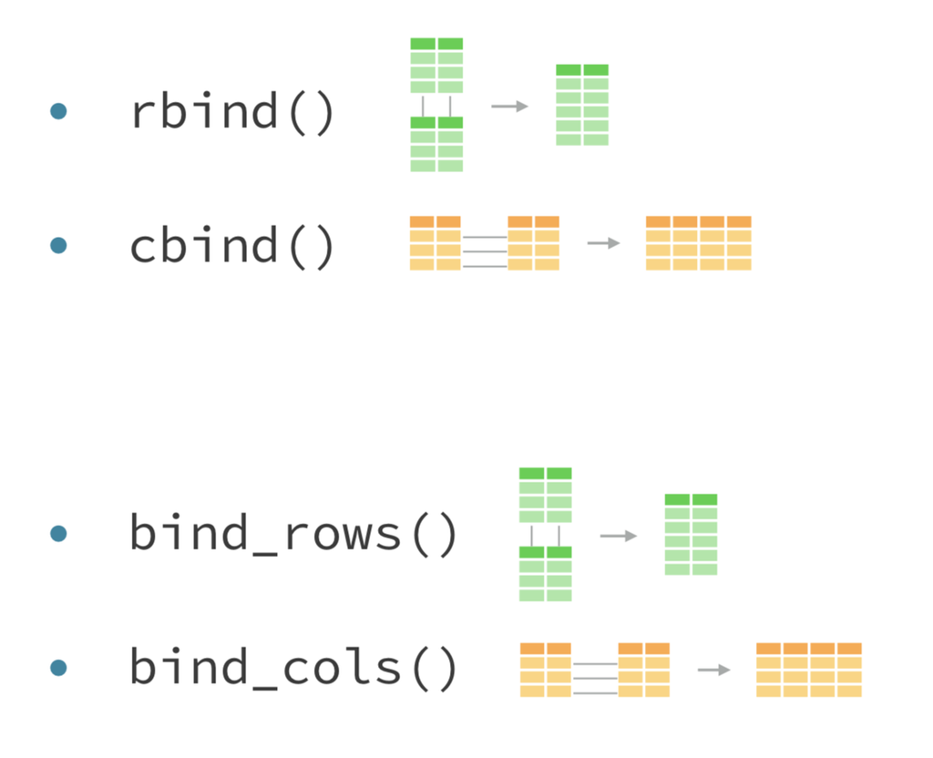

#

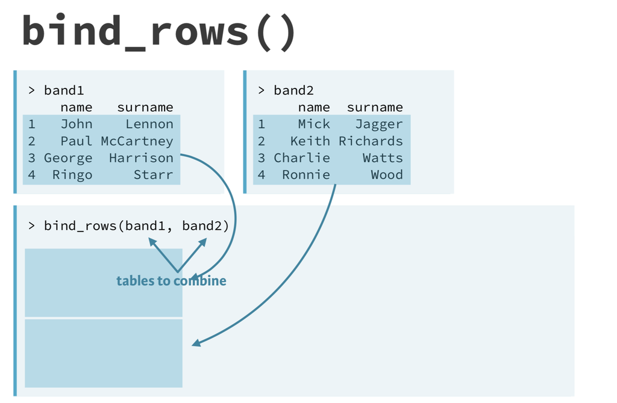

#

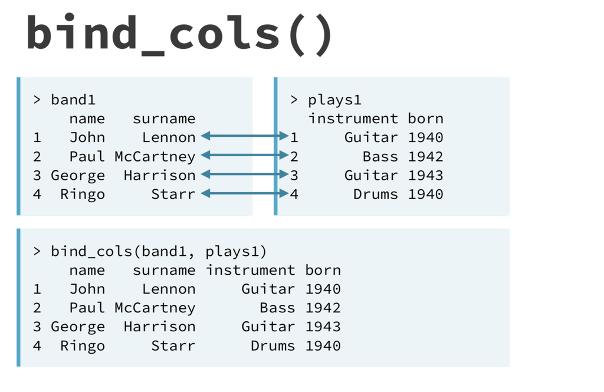

`r`r bmi <- rnorm(20,mean=30,sd=5) pat_id <- dm2$PAT_ID pat.bmi <- bind_cols(as.data.frame(pat_id),as.data.frame(bmi)) head(pat.bmi)

```
   pat_id      bmi
1 Z583990 18.72019
2 Z558145 35.90135
3 Z341881 21.92394
4 Z795049 32.95544
5 Z741693 19.25637
6 Z233337 29.21447
```

2. merge dm2 and pat.bmi

`r`r dm3 <- merge(dm2,pat.bmi,by.x=‘PAT_ID’,by.y=‘pat_id’) head(dm3)

```
   PAT_ID GENDER BIRTH_DATE DEATH_DATE           Population      bmi
1 Z127809      F  27-MAR-67       <NA>       Other Hispanic 25.35329
2 Z127919      M  14-AUG-28       <NA> AmIndAN Non-hispanic 31.01053
3 Z175070      M  18-JUL-28       <NA>   Asian Not-hispanic 36.21094
4 Z203943      M   8-SEP-46       <NA>   Caucasian Hispanic 30.44670
5 Z233337      F  18-DEC-36       <NA>            Unknown @ 29.21447
6 Z247364      F   5-DEC-44       <NA>       White Declined 27.96982
```

`r`r ggplot(dm3,aes(x=GENDER, y=bmi,color=GENDER)) + geom_boxplot()

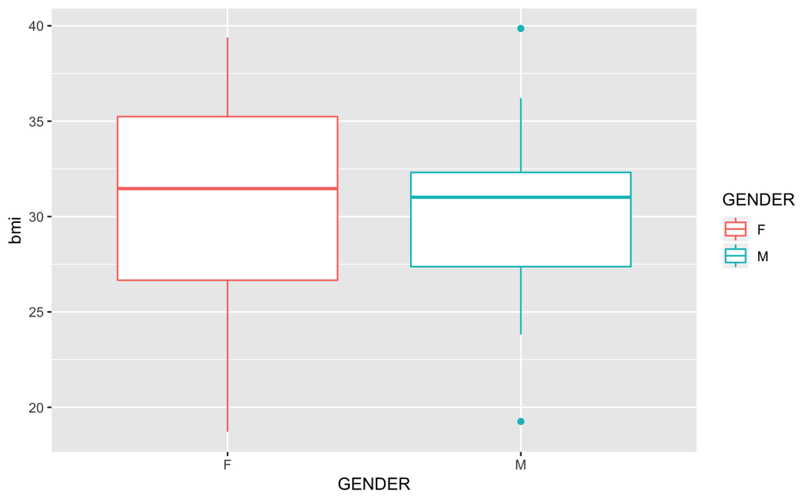

#

[figure not shown]

## Workshop

### Tibble vs Dataframe

1. How can you tell if an object is a tibble? (Hint: try printing mtcars, which is a regular data frame).

`r`r print(mtcars)

```
                     mpg cyl  disp  hp drat    wt  qsec vs am gear carb
Mazda RX4           21.0   6 160.0 110 3.90 2.620 16.46  0  1    4    4
Mazda RX4 Wag       21.0   6 160.0 110 3.90 2.875 17.02  0  1    4    4
Datsun 710          22.8   4 108.0  93 3.85 2.320 18.61  1  1    4    1
Hornet 4 Drive      21.4   6 258.0 110 3.08 3.215 19.44  1  0    3    1
Hornet Sportabout   18.7   8 360.0 175 3.15 3.440 17.02  0  0    3    2
Valiant             18.1   6 225.0 105 2.76 3.460 20.22  1  0    3    1
Duster 360          14.3   8 360.0 245 3.21 3.570 15.84  0  0    3    4
Merc 240D           24.4   4 146.7  62 3.69 3.190 20.00  1  0    4    2
Merc 230            22.8   4 140.8  95 3.92 3.150 22.90  1  0    4    2
Merc 280            19.2   6 167.6 123 3.92 3.440 18.30  1  0    4    4
Merc 280C           17.8   6 167.6 123 3.92 3.440 18.90  1  0    4    4
Merc 450SE          16.4   8 275.8 180 3.07 4.070 17.40  0  0    3    3
Merc 450SL          17.3   8 275.8 180 3.07 3.730 17.60  0  0    3    3
Merc 450SLC         15.2   8 275.8 180 3.07 3.780 18.00  0  0    3    3
Cadillac Fleetwood  10.4   8 472.0 205 2.93 5.250 17.98  0  0    3    4
Lincoln Continental 10.4   8 460.0 215 3.00 5.424 17.82  0  0    3    4
Chrysler Imperial   14.7   8 440.0 230 3.23 5.345 17.42  0  0    3    4
Fiat 128            32.4   4  78.7  66 4.08 2.200 19.47  1  1    4    1
Honda Civic         30.4   4  75.7  52 4.93 1.615 18.52  1  1    4    2
Toyota Corolla      33.9   4  71.1  65 4.22 1.835 19.90  1  1    4    1
Toyota Corona       21.5   4 120.1  97 3.70 2.465 20.01  1  0    3    1
Dodge Challenger    15.5   8 318.0 150 2.76 3.520 16.87  0  0    3    2
AMC Javelin         15.2   8 304.0 150 3.15 3.435 17.30  0  0    3    2
Camaro Z28          13.3   8 350.0 245 3.73 3.840 15.41  0  0    3    4
Pontiac Firebird    19.2   8 400.0 175 3.08 3.845 17.05  0  0    3    2
Fiat X1-9           27.3   4  79.0  66 4.08 1.935 18.90  1  1    4    1
Porsche 914-2       26.0   4 120.3  91 4.43 2.140 16.70  0  1    5    2
Lotus Europa        30.4   4  95.1 113 3.77 1.513 16.90  1  1    5    2
Ford Pantera L      15.8   8 351.0 264 4.22 3.170 14.50  0  1    5    4
Ferrari Dino        19.7   6 145.0 175 3.62 2.770 15.50  0  1    5    6
Maserati Bora       15.0   8 301.0 335 3.54 3.570 14.60  0  1    5    8
Volvo 142E          21.4   4 121.0 109 4.11 2.780 18.60  1  1    4    2
```

`r`r as.tibble(mtcars)

```
# A tibble: 32 x 11
     mpg   cyl  disp    hp  drat    wt  qsec    vs    am  gear  carb
 * <dbl> <dbl> <dbl> <dbl> <dbl> <dbl> <dbl> <dbl> <dbl> <dbl> <dbl>
 1  21       6  160    110  3.9   2.62  16.5     0     1     4     4
 2  21       6  160    110  3.9   2.88  17.0     0     1     4     4
 3  22.8     4  108     93  3.85  2.32  18.6     1     1     4     1
 4  21.4     6  258    110  3.08  3.22  19.4     1     0     3     1
 5  18.7     8  360    175  3.15  3.44  17.0     0     0     3     2
 6  18.1     6  225    105  2.76  3.46  20.2     1     0     3     1
 7  14.3     8  360    245  3.21  3.57  15.8     0     0     3     4
 8  24.4     4  147.    62  3.69  3.19  20       1     0     4     2
 9  22.8     4  141.    95  3.92  3.15  22.9     1     0     4     2
10  19.2     6  168.   123  3.92  3.44  18.3     1     0     4     4
# ... with 22 more rows
```

2. Compare and contrast the following operations on a data.frame and equivalent tibble.
- What is different?
- Why might the default data frame behaviours cause you frustration?

*data.frame*

```
[1] a
Levels: a
```

```
[1] a
Levels: a
```

```
  abc xyz
1   1   a
```

`r`r df <- tibble(abc=1,xyz=‘a’) df$xyz

```
[1] \a\
```

`r`r df[[‘xyz’]]

```
[1] \a\
```

```
# A tibble: 1 x 2
    abc xyz
  <dbl> <chr>
1     1 a
```

3. If you have the name of a variable stored in an object, e.g. var <- “mpg”, how can you extract the reference variable from a tibble?

`r`r cars <- as.tibble(mtcars) cars$mpg

4. Practice referring to non-syntactic names in the following data frame by:

```r
annoying <- tibble(`1` = 1:10,`2` = `1` * 2 + rnorm(length(`1`)))
```

- Extracting the variable called 1.

`r`r annoying$`1`

```
 [1]  1  2  3  4  5  6  7  8  9 10
```

- Plotting a scatterplot of 1 vs 2.
- Creating a new column called 3 which is 2 divided by 1.
- Renaming the columns to one, two and three.

`r`r ggplot(annoying,aes(x=`1`,y=`2`)) + geom_point()

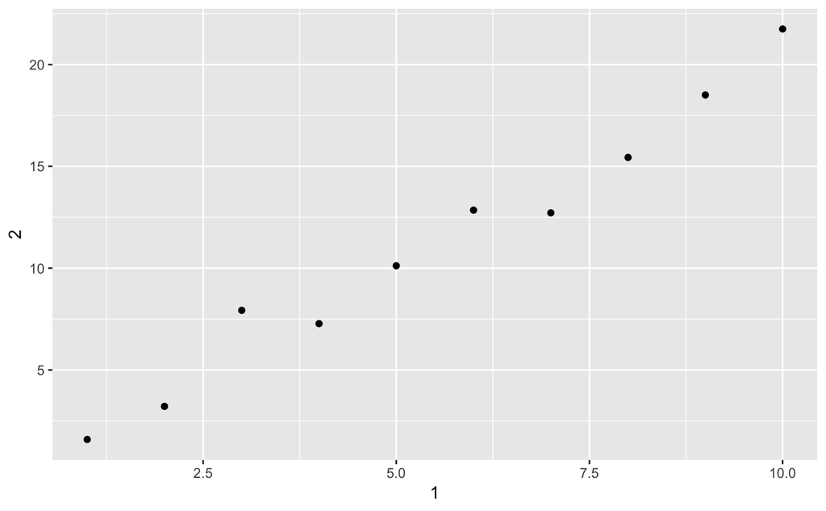

```
# A tibble: 10 x 3
     one   two three
   <int> <dbl> <dbl>
 1     1  1.58  1.58
 2     2  3.21  1.61
 3     3  7.93  2.64
 4     4  7.27  1.82
 5     5 10.1   2.02
 6     6 12.8   2.14
 7     7 12.7   1.82
 8     8 15.4   1.93
 9     9 18.5   2.06
10    10 21.7   2.17
```

5. What does tibble::enframe() do? When might you use it?

`r`r enframe(annoying$one)

```
# A tibble: 10 x 2
    name value
   <int> <int>
 1     1     1
 2     2     2
 3     3     3
 4     4     4
 5     5     5
 6     6     6
 7     7     7
 8     8     8
 9     9     9
10    10    10
```

### Reading and Writing Data

1. What function would you use to read a file where fields were separated with “|”?

   *read_delim*
2. What sort of data can be read using read_fwf()? *Read A Fixed Width File Into A Tibble*
3. Sometimes strings in a CSV file contain commas. To prevent them from causing problems they need to be surrounded by a quoting character, like " or ‘. By convention, read_csv() assumes that the quoting character will be ", and if you want to change it you’ll need to use read_delim() instead. What arguments do you need to specify to read the following text into a data frame? x,y 1,’a,b’

4. Identify what is wrong with each of the following inline CSV files. What happens when you run the code?

| a | b |
| --- | --- |
| 1 | 3 |